# Writing a reproducible paper with R Markdown and PagedownCorresponding adress: mail@paulcbauer.de, camille.landesvatter@uni-mannheim.de

# Graphs

## R base graphs

Inserting figures can be slightly more complicated. Ideally, we would produce and insert them directly in the `.rmd` file. It’s relatively simple to insert R base graphs as you can see in Figure 1.

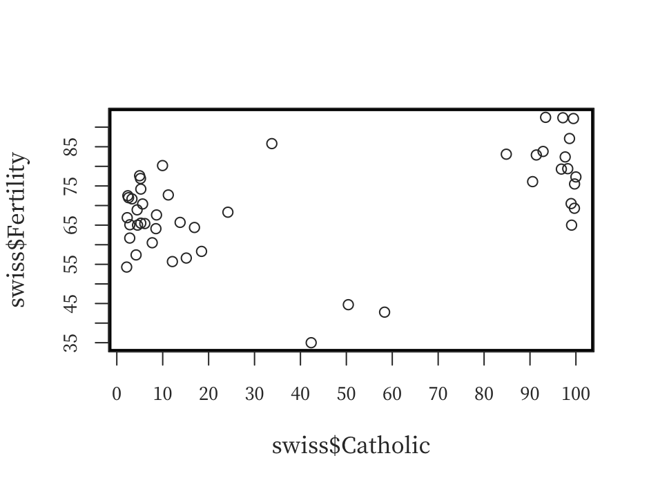

```r
R> plot(swiss$Catholic, swiss$Fertility)
```

But it turns out that it doesn’t always work so well.

## ggplot2 graphs

Same is true for ggplot2 as you can see in Figure 2.

[figure not shown]

```r
R> library(ggplot2)
R> ggplot(swiss, aes(x=Catholic, y=Fertility, shape=Education_cat)) + geom_point() +
R+   labs(x="Agriculture", y = "Fertility",
R+        shape="Education") + theme_classic()
```

# Compiling the document

To view your paper, pagedown requires a web server (since it is based on paged.js)open-source library to paginate content in the browser. By compiling a document, R Studio will display your HTML page through a local web server, i.e., paged.js will work in RStudio Viewer.

There are several options, depending on your intention:

- click on the `Knit` button in R Studio which by default will provide a HTML document in the RStudio viewer pane (the HTML will be stored in your working directory)
- use pagedown’s `chrome_print` function in the YAML (uncomment line #24 of this `Rmd` file) if additionally you want your HTML based web page to be printed to be PDF (the PDF will be stored in your working directory)
- to “live”-preview your pages do not click on the `Knit` button but use the **xaringan** (Xie 2021) RStudio add-in *Infinite Moon Reader*. You can simply call the function `xaringan::inf_mr()` (within your console). This will launch a local web server via the **servr** package (Xie 2021a) and display your pages in the RStudio viewer. Each time you save your document (*Ctrl+S*) xaringan updates your pages in the viewer.
- If you use the option `self_contained: false` (see line #21 of this `Rmd` file) (change to true for a self-contained document, but it’ll be a litte slower for Pandoc to render), don’t click on the `Knit` button in RStudio. Use instead the **xaringan** (Xie 2021) RStudio add-in *Infinite Moon Reader*.

# Good practices for reproducibility

Every researcher has his own optimized setup. Currently we would recommend the following:

- Keep all files of your project (that matter for producing the PDF) in one folder without subfolders. You can zip and directly upload that folder to the [Harvard dataverse](https://dataverse.harvard.edu/).Another good folder setup would be to store all files needed as input files for the R Markdown manuscript in a subfolder called “input” and all output files that are produced apart from paper.html and paper.pdf in a subfolder called “output”.
- Make sure that filenames have a logic to them.
  - Main file with text/code: “paper.rmd”, “report.rmd”
  - Data files: “data_xxxxxx.*”
  - Image files: “fig_xxxxxx.*”
  - Tables files: “table_xxxx.*”
  - etc.
  - Ideally, your filenames will correspond to the names in the paper. For instance, Figure 1 in the paper may have a corresponding file called `fig_1_xxxxx.pdf`.
- Use the document outline in R studio (Ctrl + Shift + O) when you work with R Markdown.
- Name rchunks according to what they do or produce:
  - “`fig-...`” for chunks producing figures
  - “`table-...`” for chunks producing tables
  - “`model-...`” for chunks producing model estimates
  - “`import-...`” for chunks importing data
  - “`recoding-...`” for chunks in which data is recoded
- Use “really” informative variable names:
  - Q: What do you think does the variable *trstep* measure? It actually measures trust in the European parliament.
    - How could we call this variable instead? Yes, `trust.european.parliament` which is longer but will probably be understood by another researcher in 50 years.
  - If your setup is truly reproducible you will probably re-use the variable names that you generate as variable names in the tables you produce. Hence, there is an incentive to use good names.
- Use unique identifiers in the final R Markdown document paper.rmd that you upload:
  - Think of someone who wants to produce Figure 1/Model 1/Table 1 in your paper but doesn’t find it in your code…
    - Name the chunks “fig-1”, “fig-2” as the are named in the published paper.
    - Name the chunks that produce tables “table-1”, “table-2” etc. as they are named in the published paper.
    - Name your statistical models in your R code “M1”, “M2” as they are named in the published paper.

# Additional tricks for publishing

- Make your script anonymous
  - Simply put a `<!-- ... -->` around any identifying information, e.g., author names, title footnote etc.
- Counting words
  - Use adobe acrobat (commerical software) to convert your file to a word file. Then open in word and delete all the parts that shouldn’t go into the word count. The word count is displayed in the lower right.
  - Use an one of the online services to count your words (search for “pdf word count”)
- Appendix: You can change the numbering format for the appendix in the rmd file
  - What is still not possible in this document is to automatically have separate reference sections for paper and appendix.
- Journals may require you to use their tex style: Sometimes you can simply use their template in your rmarkdown file. See [here](https://dataverse.harvard.edu/dataset.xhtml?persistentId=doi:10.7910/DVN/LDUMNY) for a PLOS one example.

# Citation styles

If your study needs to follow a particular citation style, you can set the corresponding style in the header of your `.rmd` document. To do so you have to download the corresponding `.csl` file.

In the present document we use the style of the American Sociological Association and set it in the preamble with `csl: american-sociological-association.csl`. However, you also need to download the respective `.csl` file from the following github page: https://github.com/citation-style-language/styles and copy it into your working directory for it to work.

The github directory contains a wide variety of citation style files depending on what discipline you work in.

# References

Bauer, Paul. 2018. “Writing a Reproducible Paper in R Markdown.” *Open Science Framework Preprint* 1–14.

Kirsop, Barbara and Leslie Chan. 2005. “Transforming Access to Research Literature for Developing Countries.” *Serials Review* 31(4):246–55.

R Core Team. 2017. *[R: A Language and Environment for Statistical Computing](https://www.R-project.org/)*. Vienna, Austria: R Foundation for Statistical Computing.

RStudio Team. 2015. *[RStudio: Integrated Development Environment for r](http://www.rstudio.com/)*. Boston, MA: RStudio, Inc.

Xie, Yihui. 2014. “[Knitr: A Comprehensive Tool for Reproducible Research in R](http://www.crcpress.com/product/isbn/9781466561595).” in *Implementing reproducible computational research*, edited by V. Stodden, F. Leisch, and R. D. Peng. Chapman; Hall/CRC.

Xie, Yihui. 2015. *[Dynamic Documents with R and Knitr](https://yihui.name/knitr/)*. 2nd ed. Boca Raton, Florida: Chapman; Hall/CRC.

Xie, Yihui. 2016. *[Bookdown: Authoring Books and Technical Documents with R Markdown](https://github.com/rstudio/bookdown)*. Boca Raton, Florida: Chapman; Hall/CRC.

Xie, Yihui. 2017. *[Bookdown: Authoring Books and Technical Documents with r Markdown](https://github.com/rstudio/bookdown)*.

Xie, Yihui. 2018. *[Knitr: A General-Purpose Package for Dynamic Report Generation in r](https://yihui.name/knitr/)*.

Xie, Yihui. 2021. *[Xaringan: Presentation Ninja](https://CRAN.R-project.org/package=xaringan)*.

Xie, Yihui and Romain Lesur. 2021. “Pagedown: Create Paged HTML Documents for Printing from R Markdown.”

Xie, Yihui, Romain Lesur, Brent Thorne, and Xianying Tan. 2021. *[Pagedown: Paginate the HTML Output of r Markdown with CSS for Print](https://CRAN.R-project.org/package=pagedown)*.

Zhu, Hao. 2017. *[kableExtra: Construct Complex Table with ’Kable’ and Pipe Syntax](https://CRAN.R-project.org/package=kableExtra)*.

# Online appendix

## Attach R session info in appendix

Since R and R packages are constantly evolving you might want to add the R session info that contains information on the R version as well as the packages that are loaded.

[session information not shown]

## All the code in the paper

To simply attach all the code you used in the PDF file in the appendix see the R chunk in the underlying `.rmd` file:

````r
R> knitr::opts_chunk$set(cache = FALSE)
R> # Use chache = TRUE if you want to speed up compilation
R> # A function to allow for showing some of the inline code
R> rinline <- function(code){
R+   html <- '<code  class="r">``` `r CODE` ```</code>'
R+   sub("CODE", code, html)
R+ }
R> remotes::install_github('rstudio/pagedown')
R> install.packages(c("rmarkdown", "knitr", "kableExtra",
R+                    "stargazer", "modelsummary", "knitr", "gt"))
R> cat(paste("#", capture.output(sessionInfo()), "\n", collapse =""))
R>   # or use message() instead of cat()
R> x <- 1:10
R> x
R> data <- read.csv("data.csv")
R> head(data)
R> dput(data[1:5,]) # here we only take a subset
R> data <- structure(list(Fertility = c(80.2, 83.1, 92.5, 85.8, 76.9), Agriculture = c(17,
R+ 45.1, 39.7, 36.5, 43.5), Examination = c(15L, 6L, 5L, 12L, 17L
R+ ), Education = c(12L, 9L, 5L, 7L, 15L), Catholic = c(9.96, 84.84,
R+ 93.4, 33.77, 5.16), Infant.Mortality = c(22.2, 22.2, 20.2, 20.3,
R+ 20.6)), class = "data.frame", row.names = c(NA, -5L))
R> library(knitr)
R> library(kableExtra)
R>
R> kable(swiss[1:10,], row.names = TRUE,
R+       caption = 'Table with kable() and kablestyling()',
R+       format = "html", booktabs = T) %>%
R+         kable_styling(full_width = T,
R+                       latex_options = c("striped",
R+                                         "scale_down",
R+                                         "HOLD_position"),
R+                       font_size = 10)
R>
R>
R> library(modelsummary)
R> datasummary_skim(swiss,
R+                  type="numeric",
R+                  histogram=T,
R+                  title = "Summary: Numeric variables")
R> # Create categorical variables
R> swiss$Education_cat <- cut(swiss$Education,
R+                    breaks=c(-Inf, 6, 12, Inf),
R+                    labels=c("low","middle","high"))
R> swiss$Infant.Mortality_cat <- cut(swiss$Infant.Mortality,
R+                    breaks=c(-Inf, 18.15, 21.70, Inf),
R+                    labels=c("low","middle","high"))
R>
R> library(flextable)
R> tab_cat <- datasummary_skim(swiss,
R+                             type="categorical",
R+                             title = "Summary: Categorical variables",
R+                             output = 'flextable')
R>
R> # additionally we want to change the font, fontsize and spacing
R> library("gdtools")
R>
R> library(dplyr)
R> tab_cat <- tab_cat %>%
R+   font(fontname="Times New Roman", part="header") %>%
R+   font(fontname="Times New Roman", j=1:4) %>%
R+   fontsize(size=12, part="header") %>%
R+   fontsize(size=10, j=1:4) %>%
R+   line_spacing(space = 0.3, part = "all")
R>
R> tab_cat
R> library(modelsummary)
R> M1 <- lm(Fertility ~ Education + Agriculture, data = swiss)
R> M2 <- lm(Fertility ~ Education + Catholic, data = swiss)
R> M3 <- lm(Fertility ~ Education + Infant.Mortality + Agriculture, data = swiss)
R> models <- list("M1" = M1, "M2" =  M2, "M3" = M3)
R>
R>
R> library(gt)
R> # additionally we want to change the font, font size and spacing
R> modelsummary(models,
R+              title = 'Linear regression',
R+              output = 'gt',
R+              notes = "Notes: some notes...") %>%
R+     tab_spanner(label = 'Dependent variable: Fertility', columns = 2:4) %>%
R+   tab_options(
R+     table.font.size = 10,
R+     data_row.padding = px(1),
R+     table.border.top.color = "white",
R+     heading.border.bottom.color = "black",
R+     row_group.border.top.color = "black",
R+     row_group.border.bottom.color = "white",
R+     table.border.bottom.color = "white",
R+     column_labels.border.top.color = "black",
R+     column_labels.border.bottom.color = "black",
R+     table_body.border.bottom.color = "black",
R+     table_body.hlines.color = "white"
R+   )
R>
R>
R> plot(swiss$Catholic, swiss$Fertility)
R> library(ggplot2)
R> ggplot(swiss, aes(x=Catholic, y=Fertility, shape=Education_cat)) + geom_point() +
R+   labs(x="Agriculture", y = "Fertility",
R+        shape="Education") + theme_classic()
R> print(sessionInfo(), local = FALSE)
````